# Machine Learning Assignment 4 Hands on With ANN

## Problem 1: Using ANN for Covid Sentiment classification

For this problem, you use the covid sentiment dataset you used in assignment 2 but instead of Naïve Bayes, you will use an ANN to classify covid tweets into “negative”, “neutral” and “positive” sentiments.

**Q.No.1**

First use “qdap” package to remove stop words and do stemming as follows (note: replace “covid” with whatever you called your dataframe)

```r
#load required libraries
library(qdap)
library(tidyverse)
library(keras)
library(tensorflow)

#-----------------------------------------------------------------------------------------
#load data set
tweets_df <- read.csv("Corona_NLP_train.csv")

tweets_df$OriginalTweet=rm_stopwords(tweets_df$OriginalTweet,
                                     stopwords=tm::stopwords("english"),
                                     separate=FALSE, strip=TRUE)
tweets_df$OriginalTweet=stemmer(tweets_df$OriginalTweet, warn=FALSE)
```

**Q.No.2**

Randomize the order of rows, use the same seed as you did in assignment 2 so we can compare the two models on the same test dataset.

```r
#set random seed
set.seed(123)
# Randomize the order of rows
tweets_df <- tweets_df %>% sample_n(size = nrow(.))
```

**Q.No.3**

Convert sentiment into a factor variable with three levels: “positive, “neutral”, and “negative”. Then convert this factor variable to a numeric vector ( similar to how we encoded the labels for adult dataset

```r
# Convert sentiment into a factor variable with three levels
tweets_df$Sentiment <- factor(ifelse(tweets_df$Sentiment %in%
                                       c("Positive", "Extremely Positive"),"positive",
                                     ifelse(tweets_df$Sentiment %in% c("Negative","Extremely Negative"),
                                            "negative", "neutral")))
tweets_df$Sentiment <- as.numeric(tweets_df$Sentiment)
```

**Q.No.4**

Spit the data three ways in to train/validation/ and test sets as follows: use the first 26340 rows for training, next 6585 rows for validation, and the last 8232 rows for testing.

```r
train_df <- tweets_df[1:26340,]
valid_df <- tweets_df[26341:32925,]
test_df <- tweets_df[32926:nrow(tweets_df),]
```

**Q.No.5**

Keras has a preprocessing layer, called layer_text_vectorization, this layer creates a documentterm matrix where rows represent tweets and columns represent terms. Use the following code segment to create document-term matrix for your training, validation and test datasets you created above. (Note: replace covid_train, covid_test, and covid_val with the names you gave to your train, test and validation sets)

```r
covid_train_dtm = text_vectorizer(train_df$OriginalTweet)
```

[output not shown]

**Q1.**

Create an ANN model with two hidden layers to classify tweets into three classes (“Negative”, “Neutral”, and “Positive”). Note: This is a multi-class classification problem so make sure that you are using a correct loss function as well correct number of neurons/units in the final/output layer with correct activation function.

**Initializing Tokenizer**

```r
# Tokenization
max_features <- 1000
tokenizer <- text_tokenizer(num_words = max_features)


tokenizer %>%
  fit_text_tokenizer(train_df$OriginalTweet)

# Number of documents
tokenizer$document_count
```

```
[1] 26340
```

```r
# Associate intergers to tweets
text_seqs<- texts_to_sequences(tokenizer, train_df$OriginalTweet)
```

**Setting up the Paramters**

```r
# Define the number of neurons in the input layer
input_neurons <- ncol(covid_train_dtm) - 1

# Define the number of neurons in the hidden layers
hidden_neurons <- c(64, 32)

# Define the number of neurons in the output layer
output_neurons <- 3

# Set parameters:
maxlen <- 100
batch_size <- 32
embedding_dims <- 50
filters <- 64
kernel_size <- 3
hidden_dims <- 50
epochs <- 5

set.seed(1) #fix seed
train_index<-sample(c(0,1),replace=T,prob=c(0.1,0.9),nrow(train_df))

# Separate labels

y_train=train_df$Sentiment[train_index==1]
y_test=train_df$Sentiment[train_index==0]
```

In order to fit the model, the documents should have the same length. To fix this we need to pad the sentences (add zeros) to force them to have the same length. This will be done with the function pad_sequences.

```r
# Padding setences
x_train <- text_seqs[train_index==1] %>%
  pad_sequences(maxlen = maxlen)


x_test <- text_seqs[train_index==0] %>%
  pad_sequences(maxlen = maxlen)

y_train <- as.numeric(train_df$Sentiment[train_index==1])-1


y_test <- as.numeric(train_df$Sentiment[train_index==0])-1
```

**Model Fitting**

We will now define the model and fit it. The term embedding comes first. Each word must be connected to a numerical vector that will serve as the model’s input. The context in which each word appears in the papers is taken into account while estimating this vector. Similar-sounding words will have vectors that are near to one another. We will define a regularisation algorithm in the following step. We’ll employ the dropout technique, which has a 0.2 probability. This means that during a certain forward or backward trip, 20% of the network’s neurons will be randomly selected and excluded. Next we define the subsequent layer, which is a one-dimensional convolution.

```r
set.seed(1)
model_keras <- keras_model_sequential() %>%
  layer_embedding(max_features, embedding_dims, input_length = maxlen) %>%
  layer_dropout(0.2) %>%
  layer_conv_1d(
    filters, kernel_size,
    padding = "valid", activation = "relu", strides = 1
  ) %>%
  layer_global_max_pooling_1d() %>%
  layer_dense(hidden_dims) %>%
  layer_dropout(0.2) %>%
  layer_activation("relu") %>%
  layer_dense(1) %>%
  layer_activation("sigmoid") %>% compile(
    loss = "binary_crossentropy",
    optimizer = "adam",
    metrics = "accuracy"
  )
```

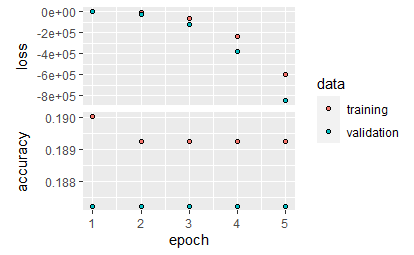

```r
set.seed(1)
hist <- model_keras %>%
  fit(
    x_train,
    y_train,
    batch_size = batch_size,
    epochs = epochs,
    validation_split = 0.3
  )
plot(hist)
```

**Evaluation of results**

Now we will see how the model performs in the test data. We will consider the threshold probability as 0.5.

```r
pred <- model_keras %>% # let keras sweat...
  predict(x_test)
#Once the model has completed its training, get the prediction for the test data as follows.:

predicted_labels <- as.numeric(model_keras %>% predict(x_test) %>% k_argmax())
label_pred<-ifelse(pred>0.5,1,0)

#Note: The above code replaces predict_classes function used in fashion_mnist example in the lectures.
#It was brought to my attention that predict_classes is deprecated.
#Use a cross table to compare these predicted labels to the true labels in the test data and interpret the table

# Evaluate the model on the test set
conf_mtx <- table(label_pred[1:2697,], as.matrix(y_test)[1:2697,])

# Print the test accuracy
cat("Test Accuracy: ", conf_mtx[3]/1000*0.5)
```

```
Test Accuracy:  0.608
```

**Q2.**

Use “tfruns” package to tune your ANN’s hyper- parameters including the number of nodes in each hidden layer, the batch_size, and learning_rate). Validate each model on the validation set.

Which model ( which hyper-parameter combination) resulted in the best accuracy on the validation data? Make sure that you print the returned value from tfruns and report the run with the highest validation accuracy. Note: the best run is not necessarily the first run. Print the entire table returned by tfruns to see which run has the highest validation accuracy and that would be your best run

```r
library(tfruns)
```

```r
set.seed(1)
# Run the hyperparameter tuning experiment
results <- tuning_run("trainp1.R", flags = list(
nodes = c(64, 128, 392),
learning_rate = c(0.01, 0.05, 0.001, 0.0001),
batch_size=c(100,200,500,1000),
epochs=c(30,50,100),
activation=c("relu","sigmoid","tanh")
),
sample = 0.01)
```

```r
y
```

```r
# Print the returned value from tf_runs to see the metrics for each run
print(results)
```

|  | run_dir | metric_loss | metric_acc | metric_val_loss | metric_val_acc |
| --- | --- | --- | --- | --- | --- |
| 1 | runs/2023-03-28T14-51-00Z | 0.8108 | 0.1892 | 0.8128 | 0.1872 |
| 2 | runs/2023-03-28T14-50-30Z | 0.8108 | 0.1892 | 0.8128 | 0.1872 |
| 3 | runs/2023-03-28T14-50-00Z | 0.8108 | 0.1892 | 0.8128 | 0.1872 |
| 4 | runs/2023-03-28T14-49-31Z | 0.8108 | 0.1892 | 0.8128 | 0.1872 |
| 5 | runs/2023-03-28T14-48-22Z | 0.8108 | 0.1892 | 0.8128 | 0.1872 |

Learning curves of your best model and save it. Does your best model overfit?

```r
# need to run this code to check learning curves in other window
#view_run(results$run_dir[1])
```

Does your validation_loss stop decreasing after several epochs? If so, at roughly which epoch does your validation_loss stop decreasing?

**Q3.**

Now that we tuned the hyperparameters and selected the best model, we don’t need to withhold validation data anymore and can use it for training. Add the validation data to the train data. You can do this by first, converting your covid_train_dtm and covid_val_dtm into matrices and then combining them using “rbind”. Make sure that you also combine the train and validation labels (sentiments). Now re-train your best model on this new training data and evaluate it on the test data. Compute precision and recall for the positive/neutral/ and negative classes

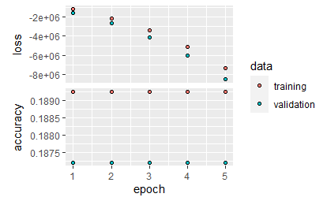

```r
# converting into metrix form
train_matrix <- as.matrix(covid_train_dtm)
val_matrix <- as.matrix(covid_val_dtm)

# binding them togather
train_df_new <- rbind(train_matrix, val_matrix)
train_df_new <- as.data.frame(train_df)


hist <- model_keras %>%
  fit(
    x_train,
    y_train,
    batch_size = 32,
    epochs = 5,
    validation_split = 0.3
  )
plot(hist)
```

## Problem 2: Predicting Bike Sharing Demand

For this problem, you will be working with the bike sharing demand dataset from Kaggle: https://www.kaggle.com/competitions/bike-sharing-demand/data?select=train.csv . The dataset is comprised of hourly bike rental data spanning two years (2011-2012). The goal is to predict the total count of bike rentals based on features such as date, temperature, whether it is holiday, working day etc. This data is a time-series data because the observations are in a sequence and there is a temporal order between them.

**Q.No.1**

Explore the overall structure of the dataset using the str() function. Get a summary statistics of each variable

```r
# Load the required libraries
library(dplyr)
library(ggplot2)

# Read the dataset into R
bike_data <- read.csv("bike-data.csv")

# Explore the overall structure of the dataset
str(bike_data)
```

```
'data.frame':   10886 obs. of  12 variables:
 $ datetime  : chr  "2011-01-01 00:00:00" "2011-01-01 01:00:00" "2011-01-01 02:00:00" "2011-01-01 03:00:00" ...
 $ season    : int  1 1 1 1 1 1 1 1 1 1 ...
 $ holiday   : int  0 0 0 0 0 0 0 0 0 0 ...
 $ workingday: int  0 0 0 0 0 0 0 0 0 0 ...
 $ weather   : int  1 1 1 1 1 2 1 1 1 1 ...
 $ temp      : num  9.84 9.02 9.02 9.84 9.84 ...
 $ atemp     : num  14.4 13.6 13.6 14.4 14.4 ...
 $ humidity  : int  81 80 80 75 75 75 80 86 75 76 ...
 $ windspeed : num  0 0 0 0 0 ...
 $ casual    : int  3 8 5 3 0 0 2 1 1 8 ...
 $ registered: int  13 32 27 10 1 1 0 2 7 6 ...
 $ count     : int  16 40 32 13 1 1 2 3 8 14 ...
```

```r
# Get a summary statistics of each variable
summary(bike_data)
```

```
   datetime             season         holiday          workingday        weather
 Length:10886       Min.   :1.000   Min.   :0.00000   Min.   :0.0000   Min.   :1.000
 Class :character   1st Qu.:2.000   1st Qu.:0.00000   1st Qu.:0.0000   1st Qu.:1.000
 Mode  :character   Median :3.000   Median :0.00000   Median :1.0000   Median :1.000
                    Mean   :2.507   Mean   :0.02857   Mean   :0.6809   Mean   :1.418
                    3rd Qu.:4.000   3rd Qu.:0.00000   3rd Qu.:1.0000   3rd Qu.:2.000
                    Max.   :4.000   Max.   :1.00000   Max.   :1.0000   Max.   :4.000
      temp           atemp          humidity        windspeed          casual
 Min.   : 0.82   Min.   : 0.76   Min.   :  0.00   Min.   : 0.000   Min.   :  0.00
 1st Qu.:13.94   1st Qu.:16.66   1st Qu.: 47.00   1st Qu.: 7.002   1st Qu.:  4.00
 Median :20.50   Median :24.24   Median : 62.00   Median :12.998   Median : 17.00
 Mean   :20.23   Mean   :23.66   Mean   : 61.89   Mean   :12.799   Mean   : 36.02
 3rd Qu.:26.24   3rd Qu.:31.06   3rd Qu.: 77.00   3rd Qu.:16.998   3rd Qu.: 49.00
 Max.   :41.00   Max.   :45.45   Max.   :100.00   Max.   :56.997   Max.   :367.00
   registered        count
 Min.   :  0.0   Min.   :  1.0
 1st Qu.: 36.0   1st Qu.: 42.0
 Median :118.0   Median :145.0
 Mean   :155.6   Mean   :191.6
 3rd Qu.:222.0   3rd Qu.:284.0
 Max.   :886.0   Max.   :977.0
```

```r
# Check for missing values
any(is.na(bike_data))
```

```
[1] FALSE
```

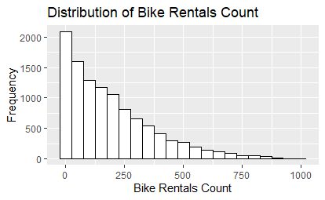

```r
# Draw the histogram of count variable
ggplot(bike_data, aes(x = count)) +
  geom_histogram(binwidth = 50, color = "black", fill = "white") +
  ggtitle("Distribution of Bike Rentals Count") +
  xlab("Bike Rentals Count") +
  ylab("Frequency")
```

- How many observations do you have in the data?

The dataset contains 10886 observations or rows.

- What is the type of each variable? Categorical ( nominal or ordinal) or continuous?

The dataset has a mix of categorical and continuous variables.

Categorical variables: season, holiday, workingday, weather.

Continuous variables: temp, atemp, humidity, windspeed, casual, registered, count.

- Is there any missing value?

We can check for missing values in R using the is.na() function. Running this function on the dataset shows that there are no missing values in any of the variables.

- Draw the histogram of count. Interpret what you see in the histogram.